## #Week 6: Analysis of longitudinal data

Import all necessary libraries.

```r
library(dplyr)
```

```r
library(tidyr)
library(ggplot2)
```

Import the RATS data and display it.

```r
RATS <- read.table("https://raw.githubusercontent.com/KimmoVehkalahti/MABS/master/Examples/data/rats.txt", sep='\t', header=TRUE)
RATS
```

```
##    ID Group WD1 WD8 WD15 WD22 WD29 WD36 WD43 WD44 WD50 WD57 WD64
## 1   1     1 240 250  255  260  262  258  266  266  265  272  278
## 2   2     1 225 230  230  232  240  240  243  244  238  247  245
## 3   3     1 245 250  250  255  262  265  267  267  264  268  269
## 4   4     1 260 255  255  265  265  268  270  272  274  273  275
## 5   5     1 255 260  255  270  270  273  274  273  276  278  280
## 6   6     1 260 265  270  275  275  277  278  278  284  279  281
## 7   7     1 275 275  260  270  273  274  276  271  282  281  284
## 8   8     1 245 255  260  268  270  265  265  267  273  274  278
## 9   9     2 410 415  425  428  438  443  442  446  456  468  478
## 10 10     2 405 420  430  440  448  460  458  464  475  484  496
## 11 11     2 445 445  450  452  455  455  451  450  462  466  472
## 12 12     2 555 560  565  580  590  597  595  595  612  618  628
## 13 13     3 470 465  475  485  487  493  493  504  507  518  525
## 14 14     3 535 525  530  533  535  540  525  530  543  544  559
## 15 15     3 520 525  530  540  543  546  538  544  553  555  548
## 16 16     3 510 510  520  515  530  538  535  542  550  553  569
```

The set comprises of 16 rats divided into 3 different groups, depending on the diet they were put on. The table shows the weight development for each rat (each figure is weight at that time in grams).

Next we draw the plot for this set, differentiating between the diet groups. But before that we need to convert the set into long form.

```r
RATS$ID <- factor(RATS$ID)
RATS$Group <- factor(RATS$Group)

RATSL <- RATS %>% gather(key = WD, value = Weight, -ID, -Group) %>% mutate(Time = as.integer(substr(WD, 3, 4)))
```

And now we draw the plot, with the set in long form.

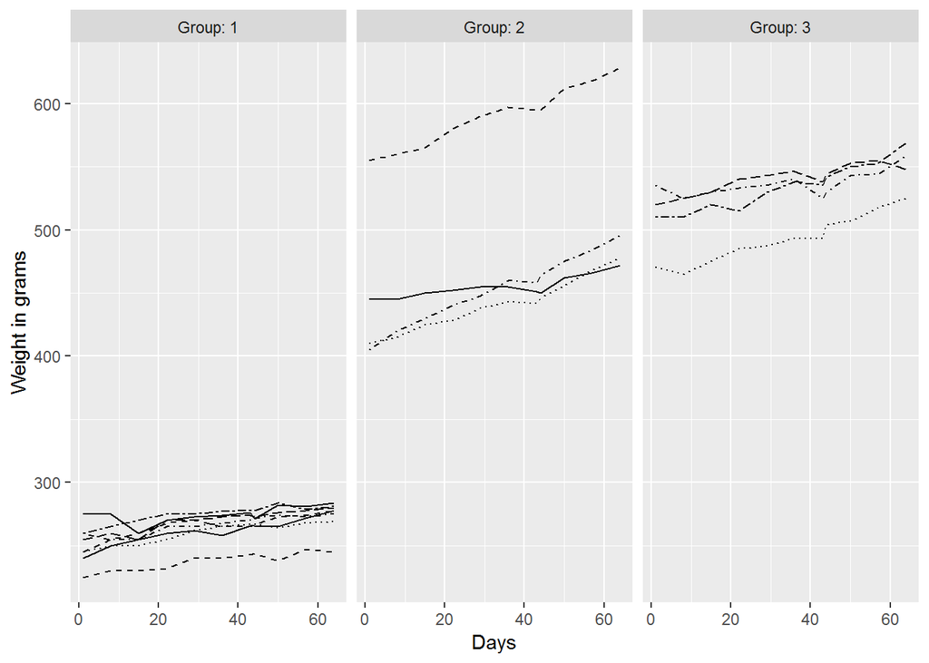

```r
ggplot(RATSL, aes(x = Time, y = Weight, linetype = ID)) +
  geom_line() +
  xlab("Days") +
  ylab("Weight in grams") +
  scale_linetype_manual(values = rep(1:10, times=4)) +
  facet_grid(. ~ Group, labeller = label_both) +
  theme(legend.position = "none")
```

As we can see, there individuals start out with vastly different weights. In general the rats in the first group weigh half as much as the ones in 2 and 3. The rats in group 2 clearly gain the most weight, group 3 almost as much, but the ones in 1 gain almost no weight.

This following of progress in individuals over time, also known as tracking, can be done better with standardized data. So next, we standardize the rat data and plot it.

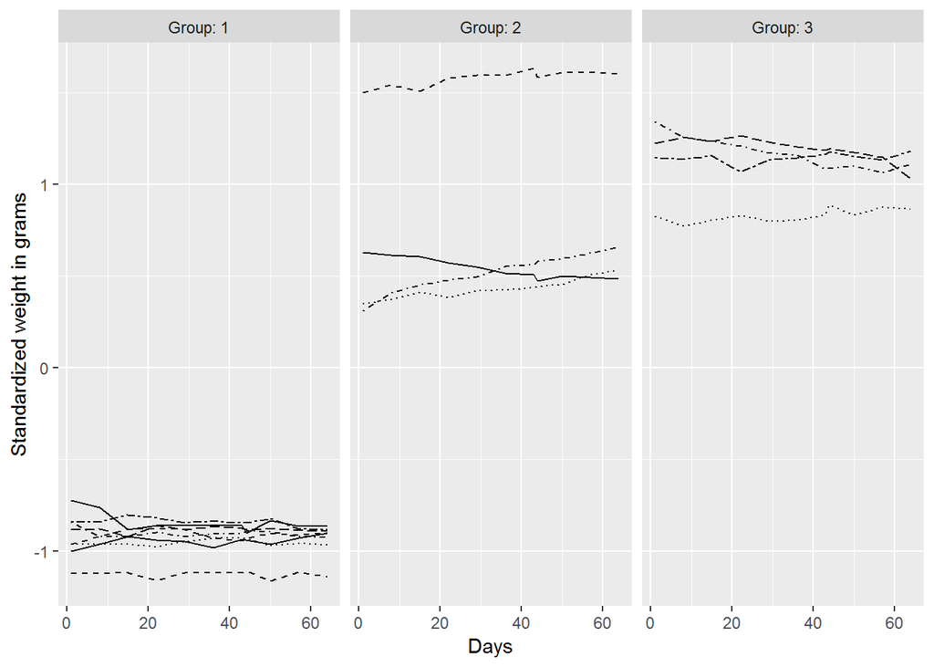

```r
RATSL <- RATSL %>%
  group_by(Time) %>%
  mutate(stdw = scale(Weight)) %>%
  ungroup()

ggplot(RATSL, aes(x = Time, y = stdw, linetype = ID)) +
  geom_line() +
  xlab("Days") +
  ylab("Standardized weight in grams") +
  scale_linetype_manual(values = rep(1:10, times=4)) +
  facet_grid(. ~ Group, labeller = label_both) +
  theme(legend.position = "none")
```

Now that we’ve subtracted the weight mean from the observations and divided by the standard deviation a completely different plot presents itself. By creating average profiles of each group, this method can iron out some larger differences that cause the plot to skew. In the difference here between the first and the second plot, there’s some indication of perhaps an outlier or something similar, that throws the first plot off balance. The difference is stark especially when looking at the coefficients of the lines, with more or less everyone going from weight gain in the first plot to neutral weight or even weight loss in the second plot.

As mentioned in the MABS-book, boxplot-like (summary graphs) plots can be good to spot for example potential outliers. So next, we move on to that.

```r
n <- RATSL$Time %>% unique() %>% length()

RATSS <- RATSL %>%
  group_by(Group, Time) %>%
  summarise(mean = mean(Weight), se = (sd(Weight)/sqrt(n))) %>%
  ungroup()

glimpse(RATSS)
```

```
## Observations: 33
## Variables: 4
## $ Group <fct> 1, 1, 1, 1, 1, 1, 1, 1, 1, 1, 1, 2, 2, 2, 2, 2, 2, 2, 2,...
## $ Time  <int> 1, 8, 15, 22, 29, 36, 43, 44, 50, 57, 64, 1, 8, 15, 22, ...
## $ mean  <dbl> 250.625, 255.000, 254.375, 261.875, 264.625, 265.000, 26...
## $ se    <dbl> 4.589478, 3.947710, 3.460116, 4.100800, 3.333956, 3.5529...
```

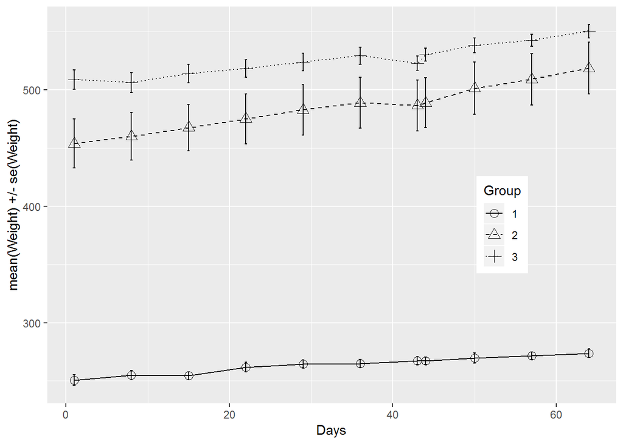

```r
ggplot(RATSS, aes(x = Time, y = mean, linetype = Group, shape = Group)) +
  geom_line() +
  scale_linetype_manual(values = c(1,2,3)) +
  geom_point(size=3) +
  scale_shape_manual(values = c(1,2,3)) +
  geom_errorbar(aes(ymin=mean-se, ymax=mean+se, linetype="1"), width=0.3) +
  theme(legend.position = c(0.8,0.45)) +
  scale_y_continuous(name = "mean(Weight) +/- se(Weight)") +
  scale_x_continuous(name = "Days")
```

Here we use mean weight profiles again with standard errors subtracted from them, which is quite indicative of the lines behaving this coherently. Worth noting though that here again the general trend has shifted towards weight gain.

For the next boxplot I’ve wasted hours on trying to get it to work correctly, but I just can’t get the three groups to appear grouped on each x-value. Below my failed work in progress.

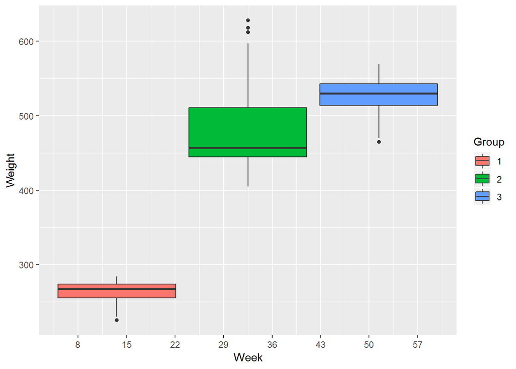

```r
ggplot(RATSL, aes(Time,Weight)) +
  geom_boxplot(aes(fill=Group)) +
  scale_x_continuous(name = "Week", breaks = seq(1, 70, 7))
```

Next we create boxplots with weight means over the course of the handful of weeks of the experiment. We exclude the first week by filtering (Time > 1).

```r
RATSLS <- RATSL %>%
  filter(Time > 1) %>%
  group_by(Group, ID) %>%
  summarise( mean=mean(Weight) ) %>%
  ungroup()

glimpse(RATSLS)
```

```
## Observations: 16
## Variables: 3
## $ Group <fct> 1, 1, 1, 1, 1, 1, 1, 1, 2, 2, 2, 2, 3, 3, 3, 3
## $ ID    <fct> 1, 2, 3, 4, 5, 6, 7, 8, 9, 10, 11, 12, 13, 14, 15, 16
## $ mean  <dbl> 263.2, 238.9, 261.7, 267.2, 270.9, 276.2, 274.6, 267.5, ...
```

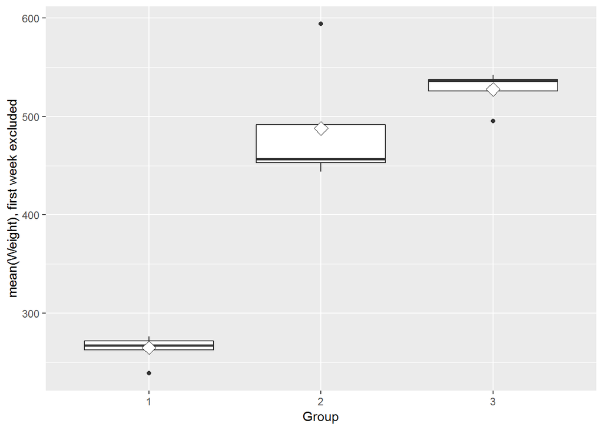

```r
ggplot(RATSLS, aes(x = Group, y = mean)) +
  geom_boxplot() +
  stat_summary(fun.y = "mean", geom = "point", shape=23, size=4, fill = "white") +
  scale_y_continuous(name = "mean(Weight), first week excluded")
```

```r
RATSLS <- RATSL %>%
  filter(Time > 1, Weight < 550) %>%
  group_by(Group, ID) %>%
  summarise( mean=mean(Weight) ) %>%
  ungroup()

glimpse(RATSLS)
```

```
## Observations: 15
## Variables: 3
## $ Group <fct> 1, 1, 1, 1, 1, 1, 1, 1, 2, 2, 2, 3, 3, 3, 3
## $ ID    <fct> 1, 2, 3, 4, 5, 6, 7, 8, 9, 10, 11, 13, 14, 15, 16
## $ mean  <dbl> 263.2000, 238.9000, 261.7000, 267.2000, 270.9000, 276.20...
```

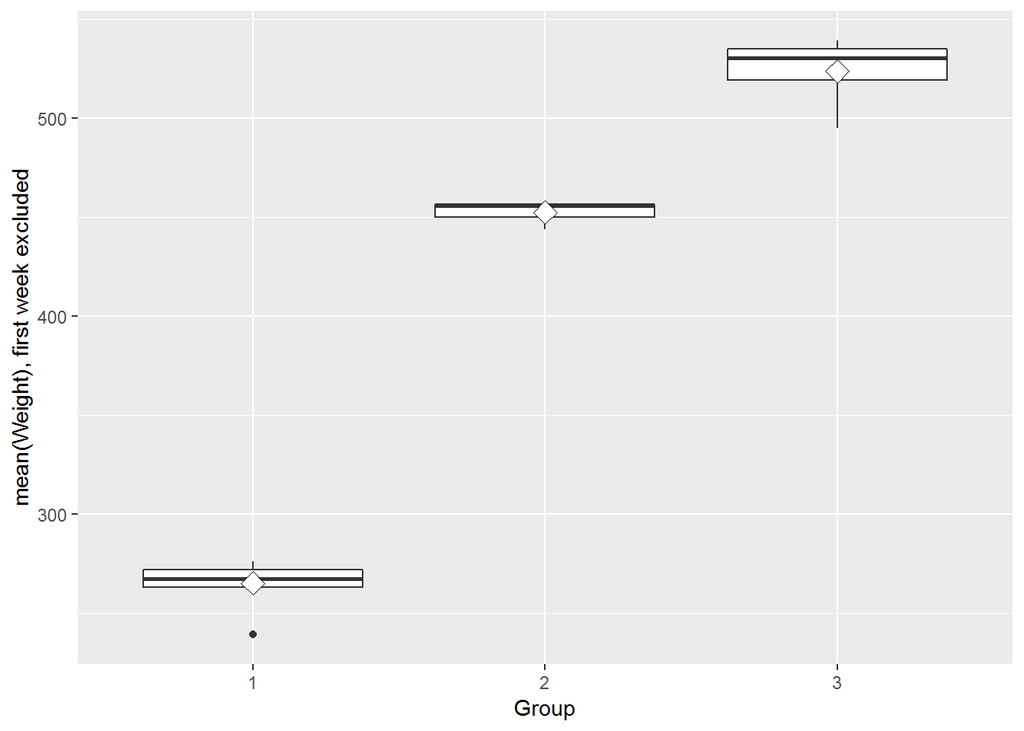

```r
ggplot(RATSLS, aes(x = Group, y = mean)) +
  geom_boxplot() +
  stat_summary(fun.y = "mean", geom = "point", shape=23, size=4, fill = "white") +
  scale_y_continuous(name = "mean(Weight), first week excluded")
```

On to t-tests.

Rstudio completely refused to take my code on the t-tests citing problem after problem, so the part on the t-test is accounted for below in plain text.

RATSLS <- RATSL %>% filter(Time > 1, Weight < 550) %>% group_by(Group, ID) %>% summarise( mean=mean(Weight) ) %>% ungroup()

t.test(mean, Group, data = RATSLS, var.equal = TRUE)

Next we add the baseline (day zero, so to speak, before the beginning of the experiment) to the covariance analysis.

RATSLS2 <- RATSLS %>% mutate(baseline = RATS$WD1)

Then we fit the linear model with the mean weight as response and the initial weight and diet group as explanatories.

fit <- lm(mean ~ baseline + Group, data = RATSLS2)

anova(fit)

Moving on to the second part, with analysis of the BPRS data. Next we’ll import it and view it in its original wide form and then in long form.

```r
BPRS <- read.table("https://raw.githubusercontent.com/KimmoVehkalahti/MABS/master/Examples/data/BPRS.txt", sep=" ", header=TRUE)

glimpse(BPRS)
```

```
## Observations: 40
## Variables: 11
## $ treatment <int> 1, 1, 1, 1, 1, 1, 1, 1, 1, 1, 1, 1, 1, 1, 1, 1, 1, 1...
## $ subject   <int> 1, 2, 3, 4, 5, 6, 7, 8, 9, 10, 11, 12, 13, 14, 15, 1...
## $ week0     <int> 42, 58, 54, 55, 72, 48, 71, 30, 41, 57, 30, 55, 36, ...
## $ week1     <int> 36, 68, 55, 77, 75, 43, 61, 36, 43, 51, 34, 52, 32, ...
## $ week2     <int> 36, 61, 41, 49, 72, 41, 47, 38, 39, 51, 34, 49, 36, ...
## $ week3     <int> 43, 55, 38, 54, 65, 38, 30, 38, 35, 55, 41, 54, 31, ...
## $ week4     <int> 41, 43, 43, 56, 50, 36, 27, 31, 28, 53, 36, 48, 25, ...
## $ week5     <int> 40, 34, 28, 50, 39, 29, 40, 26, 22, 43, 36, 43, 25, ...
## $ week6     <int> 38, 28, 29, 47, 32, 33, 30, 26, 20, 43, 38, 37, 21, ...
## $ week7     <int> 47, 28, 25, 42, 38, 27, 31, 25, 23, 39, 36, 36, 19, ...
## $ week8     <int> 51, 28, 24, 46, 32, 25, 31, 24, 21, 32, 36, 31, 22, ...
```

```r
BPRS$treatment <- factor(BPRS$treatment)
BPRS$subject <- factor(BPRS$subject)

BPRSL <-  BPRS %>% gather(key = weeks, value = bprs, -treatment, -subject)
BPRSL <-  BPRSL %>% mutate(week = as.integer(substr(weeks, 5, 5)))

glimpse(BPRSL)
```

```
## Observations: 360
## Variables: 5
## $ treatment <fct> 1, 1, 1, 1, 1, 1, 1, 1, 1, 1, 1, 1, 1, 1, 1, 1, 1, 1...
## $ subject   <fct> 1, 2, 3, 4, 5, 6, 7, 8, 9, 10, 11, 12, 13, 14, 15, 1...
## $ weeks     <chr> "week0", "week0", "week0", "week0", "week0", "week0"...
## $ bprs      <int> 42, 58, 54, 55, 72, 48, 71, 30, 41, 57, 30, 55, 36, ...
## $ week      <int> 0, 0, 0, 0, 0, 0, 0, 0, 0, 0, 0, 0, 0, 0, 0, 0, 0, 0...
```

BPRS comprises of test persons psychiatric evaluation scores over 9 weeks. In the BPRS-set the weeks can be grouped into a single column, which only uses a digit to identify said week. Above that has been done in the process to convert the set into long form.

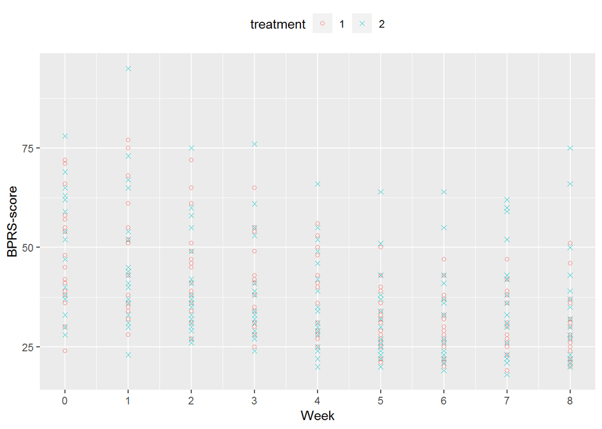

```r
ggplot(BPRSL, aes(x = week, y = bprs, linetype = treatment, fill = treatment, shape = treatment, col=treatment)) +
  geom_point() +
  scale_shape_manual(values = c(1,4)) +
  scale_x_continuous(name = "Week", breaks = seq(0, 8, 1)) + scale_y_continuous(name = "BPRS-score") + theme(legend.position = "top")
```

The general trend seems to be downward in relation to time, that is the lower the measured symptoms the longer the treatment has progressed. But any obvious difference between the treatment groups is quite hard to make out.

Next we fit the BPRSL-data to a linear regression model, below a summary of the model using the BPRS-score as the response variable and the Treatment and Week variables as explanatories.

```r
BPRSL_reg <- lm(bprs ~ week + treatment, BPRSL)

summary(BPRSL_reg)
```

```
##
## Call:
## lm(formula = bprs ~ week + treatment, data = BPRSL)
##
## Residuals:
##     Min      1Q  Median      3Q     Max
## -22.454  -8.965  -3.196   7.002  50.244
##
## Coefficients:
##             Estimate Std. Error t value Pr(>|t|)
## (Intercept)  46.4539     1.3670  33.982   <2e-16 ***
## week         -2.2704     0.2524  -8.995   <2e-16 ***
## treatment2    0.5722     1.3034   0.439    0.661
## ---
## Signif. codes:  0 '***' 0.001 '**' 0.01 '*' 0.05 '.' 0.1 ' ' 1
##
## Residual standard error: 12.37 on 357 degrees of freedom
## Multiple R-squared:  0.1851, Adjusted R-squared:  0.1806
## F-statistic: 40.55 on 2 and 357 DF,  p-value: < 2.2e-16
```

Next we have a look at a line plot illustrating the progress of the subjects over the course of the weeks. The subjects are separated by treatment groups.

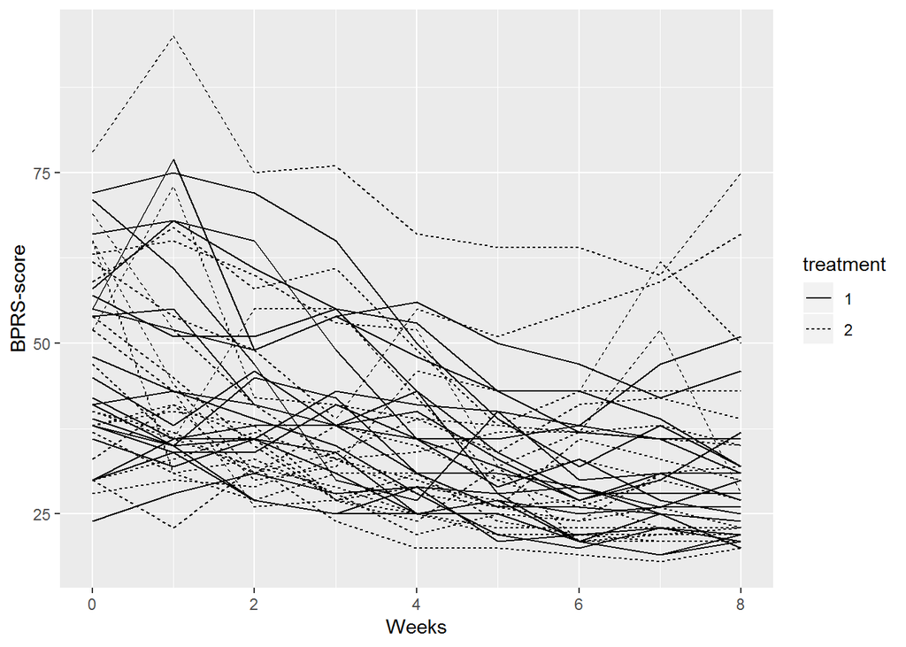

```r
BPRSL %>%
  mutate(uID = paste(treatment,subject, sep="_")) %>%
  ggplot(., aes(x = week, y = bprs, group = uID)) +
  geom_line(aes(linetype = treatment)) +
  xlab("Weeks") +
  ylab("BPRS-score")
```

The line plot doesn’t give any surprises in relation to the point plot above. Same here, the treatment group 2 can someplaces maybe be identified as having higher BPRS-scores but in general there’s massive overlapping between the two groups.

Next, a scatterplot matrix of the original BPRS-data with BPRS-scores across the weeks.

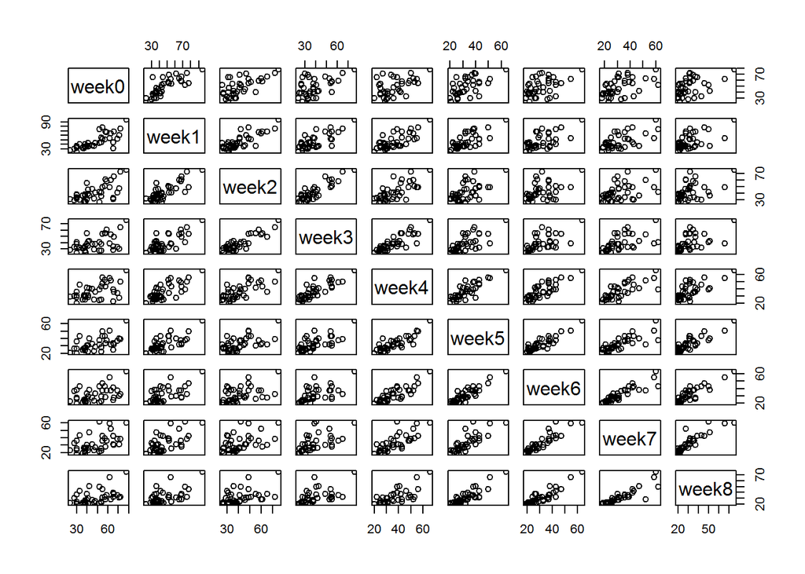

```r
pairs(BPRS[,3:11])
```

Next we fit a random intercept model with Week and Treatment as explanatory variables and the BPRS-scores as response variable.

```r
library(lme4)
BPRS_ref <- lmer(bprs ~ week + treatment + (1 | subject), data = BPRSL, REML = FALSE)

summary(BPRS_ref)
```

```
## Linear mixed model fit by maximum likelihood  ['lmerMod']
## Formula: bprs ~ week + treatment + (1 | subject)
##    Data: BPRSL
##
##      AIC      BIC   logLik deviance df.resid
##   2748.7   2768.1  -1369.4   2738.7      355
##
## Scaled residuals:
##     Min      1Q  Median      3Q     Max
## -3.0481 -0.6749 -0.1361  0.4813  3.4855
##
## Random effects:
##  Groups   Name        Variance Std.Dev.
##  subject  (Intercept)  47.41    6.885
##  Residual             104.21   10.208
## Number of obs: 360, groups:  subject, 20
##
## Fixed effects:
##             Estimate Std. Error t value
## (Intercept)  46.4539     1.9090  24.334
## week         -2.2704     0.2084 -10.896
## treatment2    0.5722     1.0761   0.532
##
## Correlation of Fixed Effects:
##            (Intr) week
## week       -0.437
## treatment2 -0.282  0.000
```

Next we expand to a random intercept and random slope model.

```r
BPRS_ref1 <- lmer(bprs ~ week + treatment + (week | subject), data = BPRSL, REML = FALSE)

summary(BPRS_ref1)
```

```
## Linear mixed model fit by maximum likelihood  ['lmerMod']
## Formula: bprs ~ week + treatment + (week | subject)
##    Data: BPRSL
##
##      AIC      BIC   logLik deviance df.resid
##   2745.4   2772.6  -1365.7   2731.4      353
##
## Scaled residuals:
##     Min      1Q  Median      3Q     Max
## -2.8919 -0.6194 -0.0691  0.5531  3.7976
##
## Random effects:
##  Groups   Name        Variance Std.Dev. Corr
##  subject  (Intercept) 64.8202  8.0511
##           week         0.9608  0.9802   -0.51
##  Residual             97.4307  9.8707
## Number of obs: 360, groups:  subject, 20
##
## Fixed effects:
##             Estimate Std. Error t value
## (Intercept)  46.4539     2.1052  22.066
## week         -2.2704     0.2977  -7.626
## treatment2    0.5722     1.0405   0.550
##
## Correlation of Fixed Effects:
##            (Intr) week
## week       -0.582
## treatment2 -0.247  0.000
```

```r
BPRS_ref2 <- lmer(bprs ~ (week*treatment) + week + treatment + (1 | subject), data = BPRSL, REML = FALSE)

summary(BPRS_ref2)
```

```
## Linear mixed model fit by maximum likelihood  ['lmerMod']
## Formula: bprs ~ (week * treatment) + week + treatment + (1 | subject)
##    Data: BPRSL
##
##      AIC      BIC   logLik deviance df.resid
##   2747.7   2771.1  -1367.9   2735.7      354
##
## Scaled residuals:
##     Min      1Q  Median      3Q     Max
## -3.2038 -0.6641 -0.0846  0.4837  3.6049
##
## Random effects:
##  Groups   Name        Variance Std.Dev.
##  subject  (Intercept)  47.46    6.889
##  Residual             103.31   10.164
## Number of obs: 360, groups:  subject, 20
##
## Fixed effects:
##                 Estimate Std. Error t value
## (Intercept)      47.8856     2.0795  23.027
## week             -2.6283     0.2934  -8.958
## treatment2       -2.2911     1.9755  -1.160
## week:treatment2   0.7158     0.4149   1.725
##
## Correlation of Fixed Effects:
##             (Intr) week   trtmn2
## week        -0.564
## treatment2  -0.475  0.594
## wek:trtmnt2  0.399 -0.707 -0.840
```

Now we can compare the observed BPRS-scores with the scores from the fitted model.

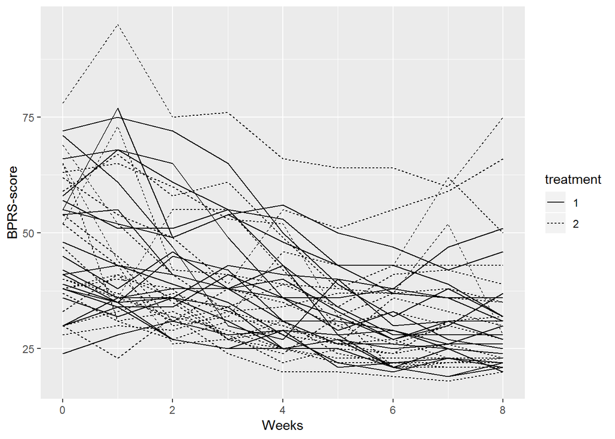

```r
p1 <- BPRSL %>%
  mutate(uID = paste(treatment,subject, sep="_")) %>%
  ggplot(., aes(x = week, y = bprs, group = uID)) +
  geom_line(aes(linetype = treatment)) +
  xlab("Weeks") +
  ylab("BPRS-score")

Fitted <- fitted(BPRS_ref2)
BPRSL$Fitted <- Fitted

p2 <- BPRSL %>%
  mutate(uID = paste(treatment,subject, sep="_")) %>%
  ggplot(., aes(x = week, y = Fitted, group = uID)) +
  geom_line(aes(linetype = treatment)) +
  xlab("Weeks") +
  ylab("Fitted BPRS-score")

p1
```

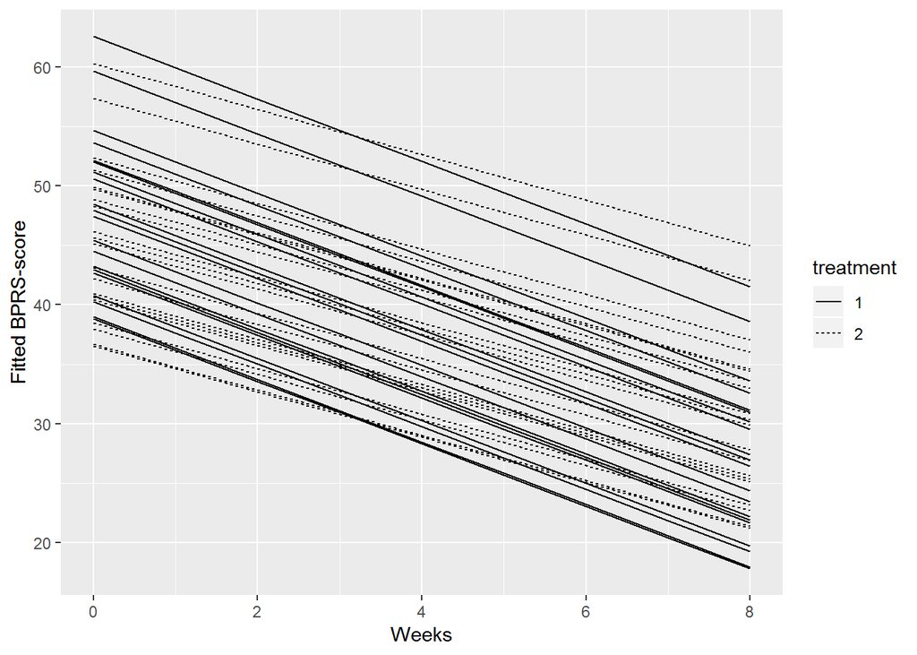

```r
p2
```